# American River

Sadie Gill, Mark Tompkins, Liz Stebbins, Erin Cain

May 2024

## Future Data Improvements

None planned.

## Instream Spawning and Rearing Habitat

**Data Source:** [ARWA 2017](https://s3-us-west-2.amazonaws.com/cvpiahabitat-r-package/cvpia-sit-model-inputs/ARWA-702.pdf) (pgs. 91-107) and [CBEC Eco Engineering 2021](https://r2r-habitat-docs.s3.amazonaws.com/17-1005_LAR_Rearing_WUA_2021-11-08.pdf).

The instream spawning habitat for Fall Run Chinook Salmon and Steelhead in the American River is based on a spawning habitat suitability and availability analysis performed by the Sacramento Water Forum. The Water Forum conducted the analysis as part of the Lower American River Biological Rationale Development and Performance of the Modified Flow Standard (ARWA 2017).

The instream juvenile rearing habitat for Fall Run Chinook Salmon was provided by Chris Hammersmark, CBEC Eco Engineering. The weighted usuable area (WUA) values were produced in units of acres and were converted to square meters for instream rearing (but kept in acres for floodplain). These were not differentiated by lifestage and so are the same for juveniles and fry.

### Spawning Data

Header Descriptions: flow_cfs = flow in cubic feet per second, FR_spawn_sqm = Fall Run Chinook Spawning (square meters), ST_spawn_sqm = Steelhead Spawning (square meters), watershed = section of stream modeled for CVPIA SDM

| flow_cfs | FR_spawn_sqm | ST_spawn_sqm | watershed |
| --- | --- | --- | --- |
| 500 | 128256.10 | 111239.11 | American River |
| 1000 | 162238.59 | 141084.07 | American River |
| 2000 | 171152.84 | 143100.54 | American River |
| 15000 | 18927.72 | 12641.06 | American River |
| 0 | 0.00 | 0.00 | American River |

*…with 40 more rows.*

### Rearing Data

Header Descriptions: flow_cfs = flow in cubic feet per second, FR_fry_sqm = Fall Run Chinook Fry WUA in square meters, FR_juv_sqm = Fall Run Chinook Juvenile WUA in square meters, watershed = section of stream modeled for CVPIA SDM

| flow_cfs | FR_fry_sqm | FR_juv_sqm | watershed |
| --- | --- | --- | --- |
| 500 | 322491.7 | 322491.7 | American River |
| 800 | 322085.5 | 322085.5 | American River |
| 1000 | 326565.2 | 326565.2 | American River |
| 1250 | 329522.7 | 329522.7 | American River |
| 1500 | 333708.7 | 333708.7 | American River |

*…with 6 more rows.*

### Spawning WUA

The Fall Run Chinook Salmon and Steelhead spawning habitat data from [ARWA 2017](https://s3-us-west-2.amazonaws.com/cvpiahabitat-r-package/cvpia-sit-model-inputs/ARWA-702.pdf) is located in Attachment B. Fall Run Chinook Salmon data are in Table B-4 on page 91 and Figure B-8 on page 92. Steelhead data are in Table B-9 and Figure B-26 on page 107.

The following plot shows the composite WUA in acres (converted from square feet) for Fall Run Chinook Salmon and Steelhead. The WUA values combine data from all evaluation reaches. These area per length rates are multiplied by the total spawning reach length mapped by the SIT to estimate areas of habitat.

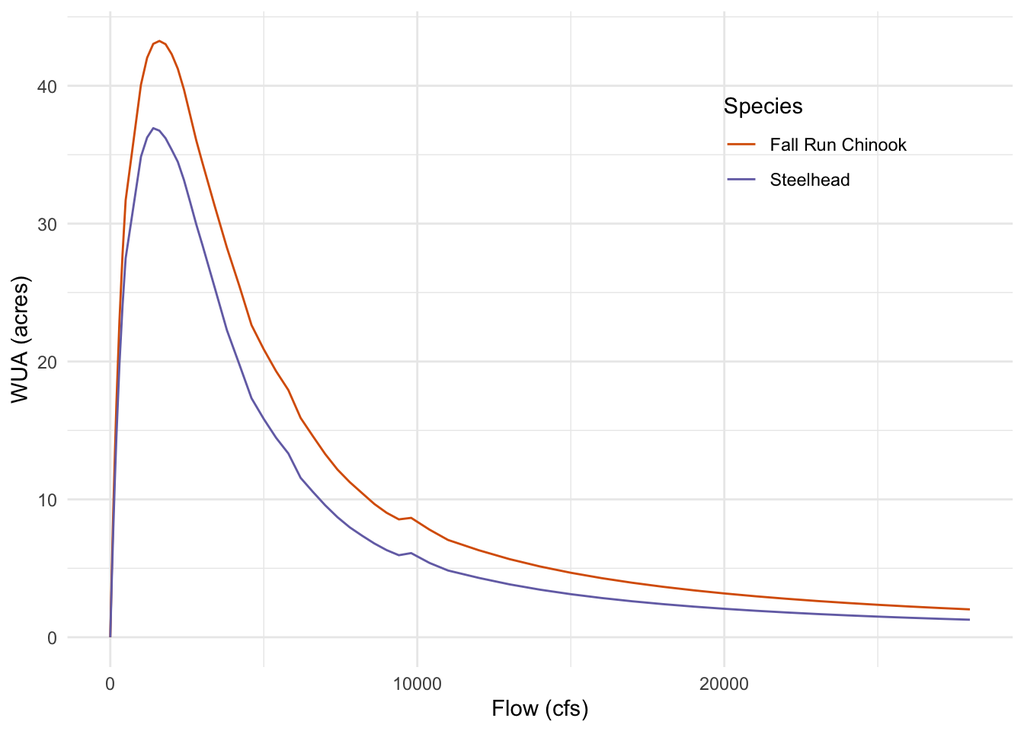

### Rearing WUA

The following plot shows the rearing WUA in acres for fry and juvenile Fall Run Chinook Salmon. WUA were produced for only one juvenile lifestage and so only one curve is visible.

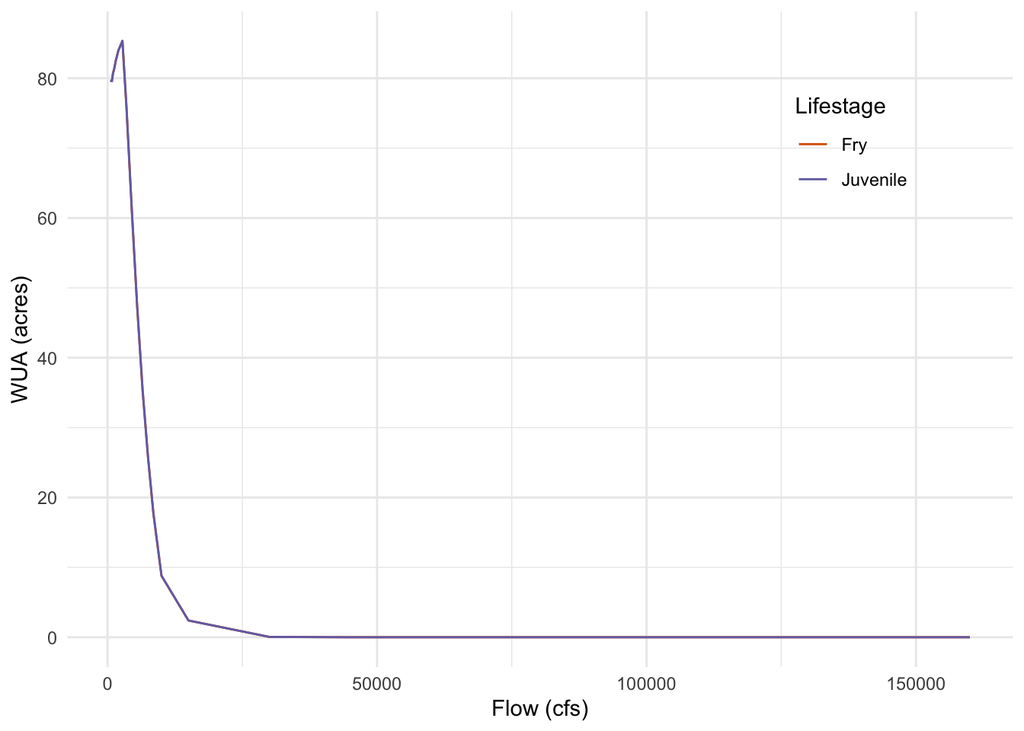

## Floodplain Rearing Habitat

**Data Source:** The floodplain juvenile rearing habitat for Fall Run Chinook Salmon was provided by Chris Hammersmark, CBEC Eco Engineering.

## Floodplain Data

The areas represent total inundated area in acres.

Header Descriptions: flow_cfs = flow in cubic feet per second, FR_floodplain_acres = Fall Run Chinook floodplain acres, ST_floodplain_acres = Steelhead floodplain acres, watershed = section of stream modeled for CVPIA SDM

| flow_cfs | FR_floodplain_acres | ST_floodplain_acres | watershed |
| --- | --- | --- | --- |
| 500 | 0 | 0 | American River |
| 800 | 0 | 0 | American River |
| 1000 | 0 | 0 | American River |
| 1250 | 0 | 0 | American River |
| 1500 | 0 | 0 | American River |

*…with 29 more rows*

## Floodplain Plot

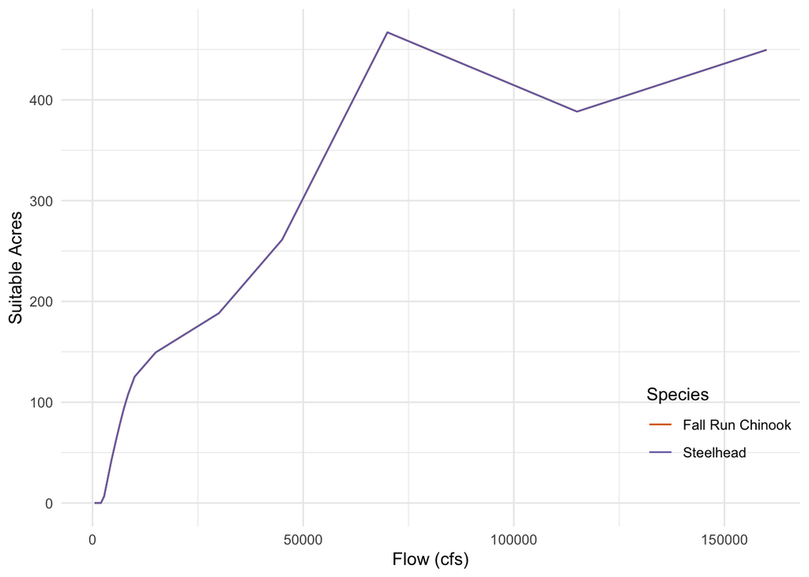